# Лабораторная работа № 7

```r
library(keras) # чтобы не отображать результат написать после r.. eval=FALSE
library(dplyr)
library(glue)
library(tidyverse)
```

```r
train_dir <- file.path("data/dogs-vs-cats/train")
test_dir <- file.path("data/dogs-vs-cats/test")
# create train, validation, and test file paths for cat images
train_cats_dir <- file.path(train_dir, "cats")
test_cats_dir <- file.path(test_dir, "cats")

# create train, validation, and test file paths for dog images
train_dogs_dir <- file.path(train_dir, "dogs")
test_dogs_dir <- file.path(test_dir, "dogs")
```

| 1. Случайное вращение |
| --- |

Вращение изображения является одним из широко используемых методов увеличения и позволяет модели стать инвариантной к ориентации объекта.

Image_Data_Generator позволяет случайным образом поворачивать изображения на любой градус от 0 до 360, предоставляя целочисленное значение в аргументе rotate_range.

Когда изображение поворачивается, некоторые пиксели перемещаются за пределы изображения и оставляют пустую область, которую необходимо заполнить. Можно заполнить это различными способами, например, постоянным значением или ближайшими значениями пикселей и т. д. Это указывается в аргументе fill_mode и значением по умолчанию является «ближайший» (nearest), который просто заменяет пустую область ближайшими значениями пикселей.

Подготовим картинку.

```r
fnames_tcat<- list.files(train_cats_dir, full.names = TRUE) #список файлов в директории
img_path<- fnames_tcat[[15]] # выберем 1 картинку под индексом 15, например
img<- image_load(img_path, target_size = c(300,300))
# преобразуем в тензор
img_array<- array_reshape(image_to_array(img), c(1, 300, 300, 3))
```

Теперь запустим преобразование.

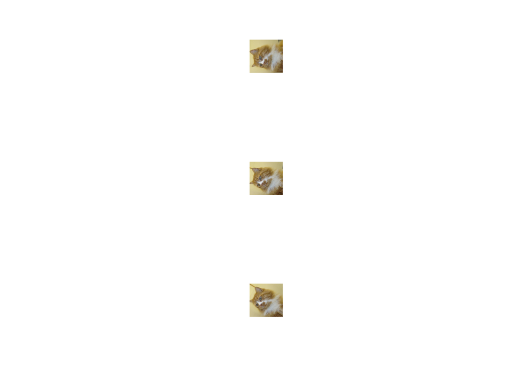

| 2. Случайный сдвиг |
| --- |

```r
datagen <- image_data_generator(rescale = 1/255, rotation_range = 190,fill_mode = "nearest" )
# rescale используется для перемасштабирования даннхы пикселей из 0-255 в 0-1, что является по сути своей нормализацией
aug_iter<- flow_images_from_data(img_array, generator = datagen,
                                 batch_size = 1)
# batch_size используется здесь для разбиения изображения на равное количество изображений, в данном случае м этого не делаем
axs<- par(mfrow = c(3,1), pty = 's')
for (i in 1:3) {
  batch<- generator_next(aug_iter)
  plot(as.raster(batch[1,,,]))
}
```

Может случиться так, что объект не всегда может находиться в центре изображения. Чтобы преодолеть эту проблему, мы можем сместить пиксели изображения либо по горизонтали, либо по вертикали; это делается путем добавления определенного постоянного значения ко всем пикселям.

Image_Data_Generator имеет аргумент **height_shift_range** для вертикального сдвига изображения и **width_shift_range** для горизонтального сдвига изображения. Если значение является числом с плавающей точкой, это будет означать процент ширины или высоты смещаемого изображения. В противном случае, если это целое значение, то просто ширина или высота смещаются этими многими значениями пикселей.

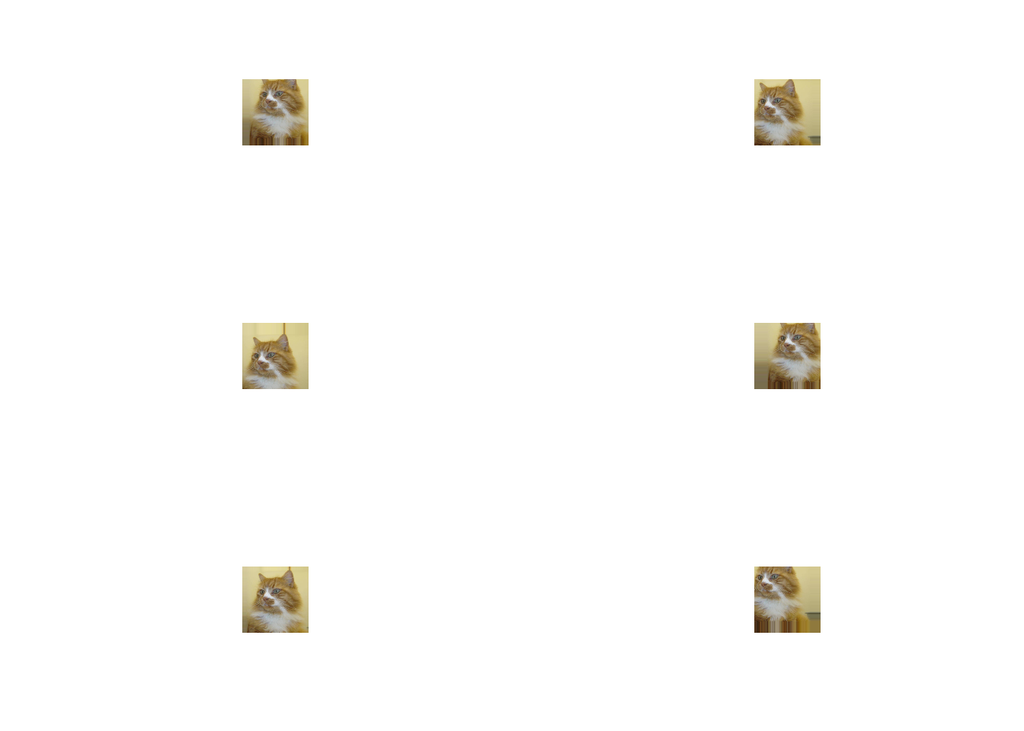

| 3. Случайный переворот |
| --- |

```r
datagen <- image_data_generator(rescale = 1/255, width_shift_range=0.2, height_shift_range=0.2)
aug_iter<- flow_images_from_data(img_array, generator = datagen,
                                 batch_size = 1)
axs<- par(mfrow = c(3,2), pty = 's')
for (i in 1:6) {
  batch<- generator_next(aug_iter)
  plot(as.raster(batch[1,,,]))
}
```

Переворачивание изображений также является отличной техникой дополнения, и имеет смысл использовать ее с большим количеством различных объектов.

Параметры **horizontal_flip** и **vertical_flip** для переворачивания вдоль вертикальной или горизонтальной оси. Эта техника должна соответствовать объекту на изображении. То есть не противоречить смыслу исследования.

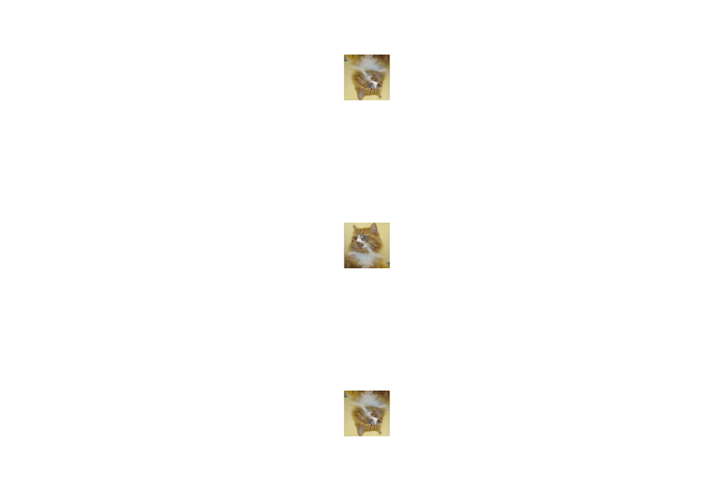

| 4. Случайная яркость |
| --- |

```r
datagen <- image_data_generator(rescale = 1/255, horizontal_flip=T, vertical_flip=T)
aug_iter<- flow_images_from_data(img_array, generator = datagen,
                                 batch_size = 1)
axs<- par(mfrow = c(3,1), pty = 's')
for (i in 1:3) {
  batch<- generator_next(aug_iter)
  plot(as.raster(batch[1,,,]))
}
```

Случайным образом изменяет яркость изображения. Это также очень полезная техника дополнения, потому что большую часть времени наш объект не будет находиться в идеальных условиях освещения.

Яркостью можно управлять с помощью аргумента **brightness_range**. Он принимает список из двух значений с плавающей точкой и выбирает значение сдвига яркости из этого диапазона. Значения менее 1,0 затемняют изображение, тогда как значения выше 1,0 осветляют изображение.

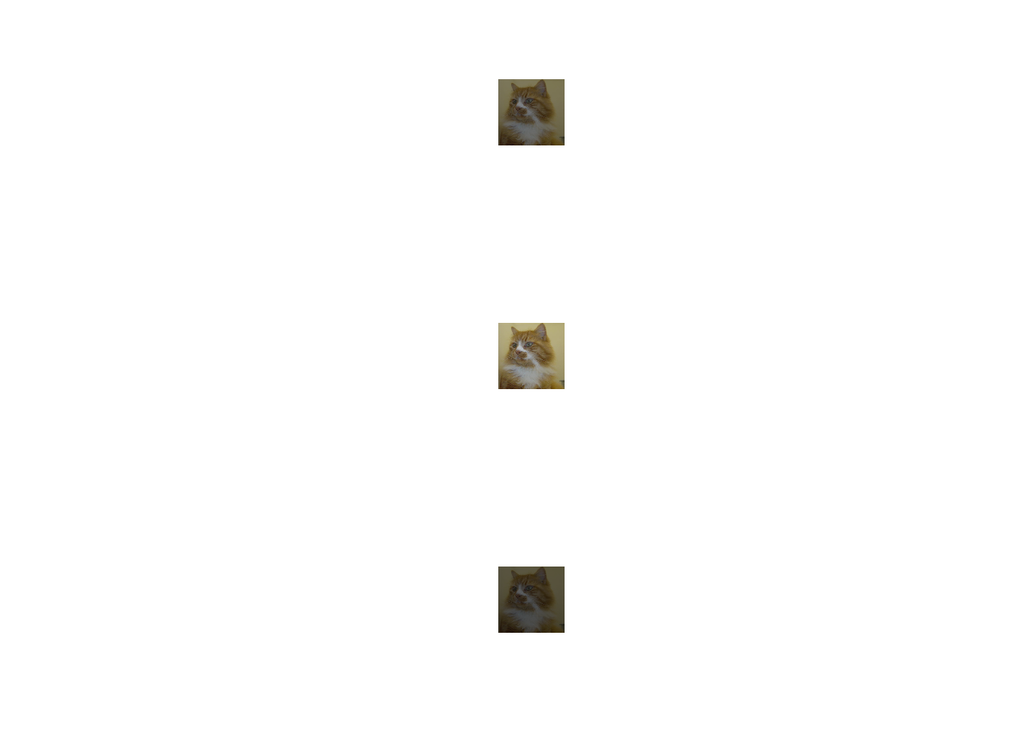

| 4. Случайный масштаб |
| --- |

```r
datagen <- image_data_generator(rescale = 1/255, brightness_range=(0.4:1.5))
aug_iter<- flow_images_from_data(img_array, generator = datagen,
                                 batch_size = 1)
axs<- par(mfrow = c(3,1), pty = 's')
for (i in 1:3) {
  batch<- generator_next(aug_iter)
  plot(as.raster(batch[1,,,]))
}
```

Увеличение масштаба либо случайным образом увеличивает изображение, либо уменьшает изображение. Принимает значение float для масштабирования аргумента **zoom_range**. Можно предоставить список с двумя значениями, указывающими нижний и верхний предел. В противном случае, если указать значение float, то масштабирование будет выполнено в диапазоне [1-zoom_range,1+zoom_range].

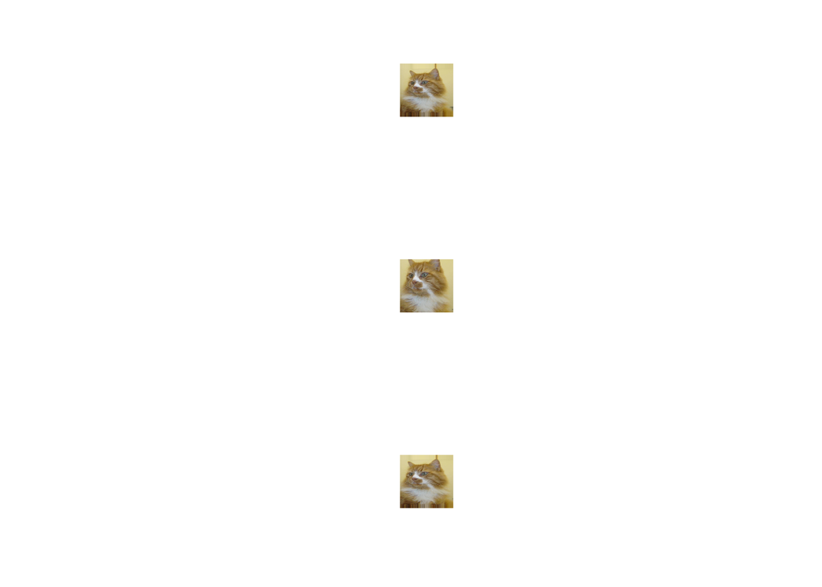

| 5. Оптимальные параметры |
| --- |

```r
datagen <- image_data_generator(rescale = 1/255, zoom_range = 0.3)
aug_iter<- flow_images_from_data(img_array, generator = datagen,
                                 batch_size = 1)
axs<- par(mfrow = c(3,1), pty = 's')
for (i in 1:3) {
  batch<- generator_next(aug_iter)
  plot(as.raster(batch[1,,,]))
}
```

Оптимальные параметры, вероятно, должны подбираться исходя из объектов исследования. В частности, в нашем примере вероятно нет смысла использовать перемасштабирвоание, т.к. форма животных в действительности не должна быть сплюченной или расплющенной.

Все остальные преобразования имеют место быть. Пример:

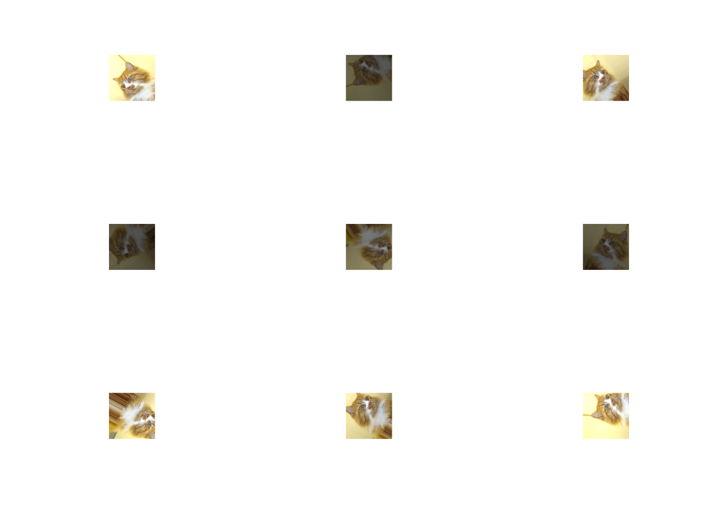

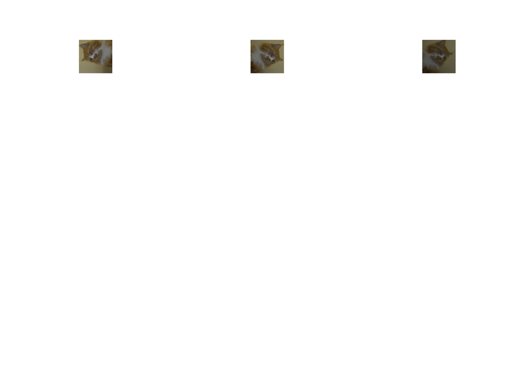

| 6. Метод flow_images_from_data() |
| --- |

```r
datagen <- image_data_generator(rescale = 1/255, rotation_range = 140,
                                width_shift_range = (0.2:0.9),
                                height_shift_range = (0.2:0.9),
                                shear_range = (0.2:0.9),
                                brightness_range=(0.4:1.5),
                                horizontal_flip = T, vertical_flip = T,
                                fill_mode = "nearest")
aug_iter<- flow_images_from_data(img_array, generator = datagen,
                                 batch_size = 1)
axs<- par(mfrow = c(3,3), pty = 's')
for (i in 1:12) {
  batch<- generator_next(aug_iter)
  plot(as.raster(batch[1,,,]))
}
```

Метод **flow_images_from_data()** позволяет считывать изображения непосредственно из меток и дополнять их, пока модель нейронной сети обучается.

```r
# Загрузка данных 2 категорий
fnames_tdog<- list.files(train_dogs_dir, full.names = TRUE)
img_path_cats<- fnames_tcat[60:69]
img_path_dogs<- fnames_tdog[60:69]
img_path<- c(img_path_cats, img_path_dogs)

loadpics = function(filenames) {
  a = lapply(filenames, image_load, target_size = c(100,100))
  b = lapply(a, image_to_array)
  c = lapply(b, array_reshape, dim = c(100, 100, 3))
  d = normalize(c, axis = 1)
  return(d)
  }

trainx = loadpics(img_path)
trainlabel = to_categorical(c(1, 1,1,1,1,1,1,1,1,1, 0, 0,0,0,0,0,0,0,0,0))

# Формирование набора из 2 изображений каждого класса

train_generator <- flow_images_from_data(x = trainx, y = trainlabel,
    datagen, batch_size = 20)
batch <- generator_next(train_generator)
str(batch)
```

```
## List of 2
##  $ : num [1:20, 1:100, 1:100, 1:3] 0 0 0 0 0 0 0 0 0 0 ...
##  $ : num [1:20, 1:2] 1 1 0 1 1 0 0 0 1 0 ...
```

Построим так же тестовую выборку.

```r
img_path_cats<- fnames_tcat[80:89]
img_path_dogs<- fnames_tdog[80:89]
img_path<- c(img_path_cats, img_path_dogs)
testx = loadpics(img_path)
testlabel = trainlabel
```

Теперь построим сверточную нейронную сеть.

CNN будет включать в себя:

```r
cnn <- keras_model_sequential() %>%
    layer_conv_2d(filters = 32, kernel_size = c(3,3), activation = "relu",
        input_shape = c(100, 100, 3)) %>%
  layer_batch_normalization()%>%
  layer_conv_2d(filters = 32, kernel_size = c(3,3), padding = 'Same',
                activation = 'relu')%>%
  layer_batch_normalization()%>%
  layer_max_pooling_2d(pool_size = c(2, 2))%>%
  layer_dropout(rate = 0.2) %>%
  layer_conv_2d(filters = 64, kernel_size = c(3,3),padding = 'Same',
                activation = 'relu')%>%
  layer_batch_normalization()%>%
  layer_conv_2d(filters = 64, kernel_size = c(3, 3), activation = "relu") %>%
  layer_max_pooling_2d(pool_size = c(2, 2)) %>%
  layer_conv_2d(filters = 64, kernel_size = c(2, 2), activation = "relu") %>%
  layer_dropout(rate = 0.2) %>%
  layer_flatten() %>%
  layer_dense(units=1024,activation='relu')%>%
  layer_dense(units=512,activation='relu')%>%
  layer_dense(units=256,activation='relu')%>%
  layer_dense(units = 2, activation = "softmax")
cnn %>% compile(
  loss = "binary_crossentropy",
  optimizer = optimizer_adam(),
  metrics = keras$metrics$AUC()
)

summary(cnn)
```

```
## Model: "sequential"
## ________________________________________________________________________________
##  Layer (type)                  Output Shape               Param #    Trainable
## ================================================================================
##  conv2d_4 (Conv2D)             (None, 98, 98, 32)         896        Y
##  batch_normalization_2 (BatchN  (None, 98, 98, 32)        128        Y
##  ormalization)
##  conv2d_3 (Conv2D)             (None, 98, 98, 32)         9248       Y
##  batch_normalization_1 (BatchN  (None, 98, 98, 32)        128        Y
##  ormalization)
##  max_pooling2d_1 (MaxPooling2D  (None, 49, 49, 32)        0          Y
##  )
##  dropout_1 (Dropout)           (None, 49, 49, 32)         0          Y
##  conv2d_2 (Conv2D)             (None, 49, 49, 64)         18496      Y
##  batch_normalization (BatchNor  (None, 49, 49, 64)        256        Y
##  malization)
##  conv2d_1 (Conv2D)             (None, 47, 47, 64)         36928      Y
##  max_pooling2d (MaxPooling2D)  (None, 23, 23, 64)         0          Y
##  conv2d (Conv2D)               (None, 22, 22, 64)         16448      Y
##  dropout (Dropout)             (None, 22, 22, 64)         0          Y
##  flatten (Flatten)             (None, 30976)              0          Y
##  dense_3 (Dense)               (None, 1024)               31720448   Y
##  dense_2 (Dense)               (None, 512)                524800     Y
##  dense_1 (Dense)               (None, 256)                131328     Y
##  dense (Dense)                 (None, 2)                  514        Y
## ================================================================================
## Total params: 32,459,618
## Trainable params: 32,459,362
## Non-trainable params: 256
## ________________________________________________________________________________
```

Запустим и построим модель.

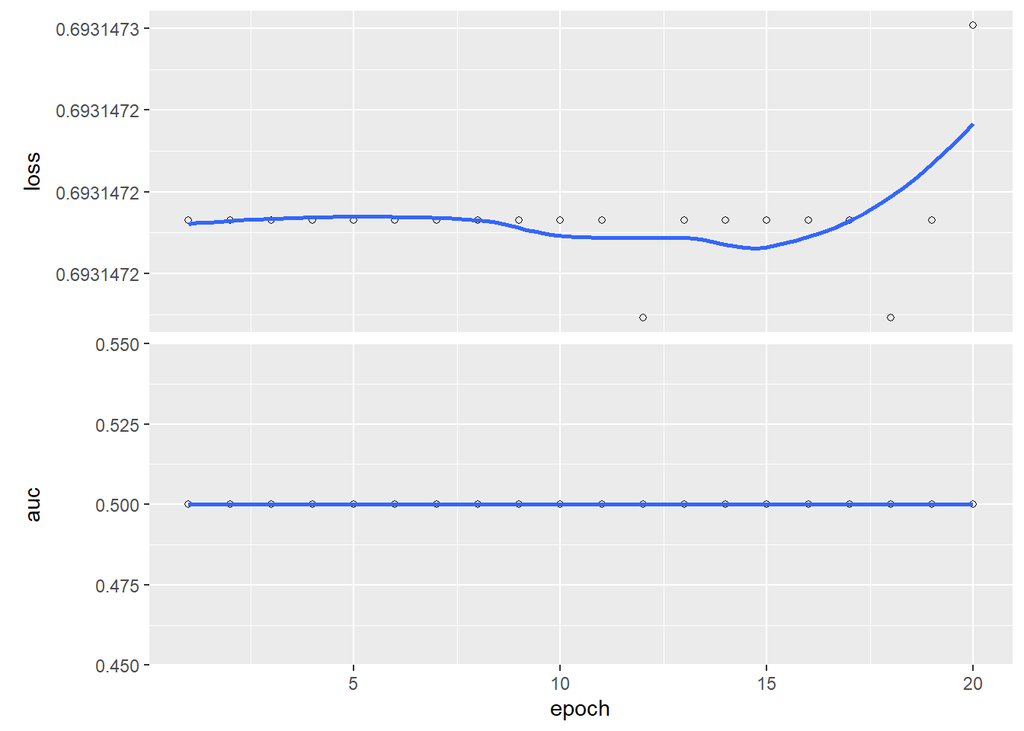

```r
history_cnn <- cnn %>%
    fit(train_generator, epochs = 20,
        verbose = 0)
plot(history_cnn)
```

```r
cnn %>%
    keras::evaluate(testx, testlabel)
```

```
##      loss       auc
## 0.6931638 0.4562500
```

Оценки успешности классификации оставляют желать лучшего. Изменим аугментацию картинок таким образом, чтобы модель стала работать лучше. Ниже представлена результирующая модель.

```r
datagen <- image_data_generator(
  featurewise_center = F,
  samplewise_center=F,
  featurewise_std_normalization = F,
  samplewise_std_normalization=F,
  zca_whitening=F,
  horizontal_flip = F,
  vertical_flip = F,
  width_shift_range = 0.15,
  height_shift_range = 0.15,
  rotation_range = 0.15,
  shear_range = 0.15)
train_generator <- flow_images_from_data(x = trainx, y = trainlabel,
    datagen, batch_size = 128)
# Определим так же тестовые данные для проверки сети:
valid_generator <- flow_images_from_data(x = testx, y = testlabel,
    datagen, batch_size = 128)
```

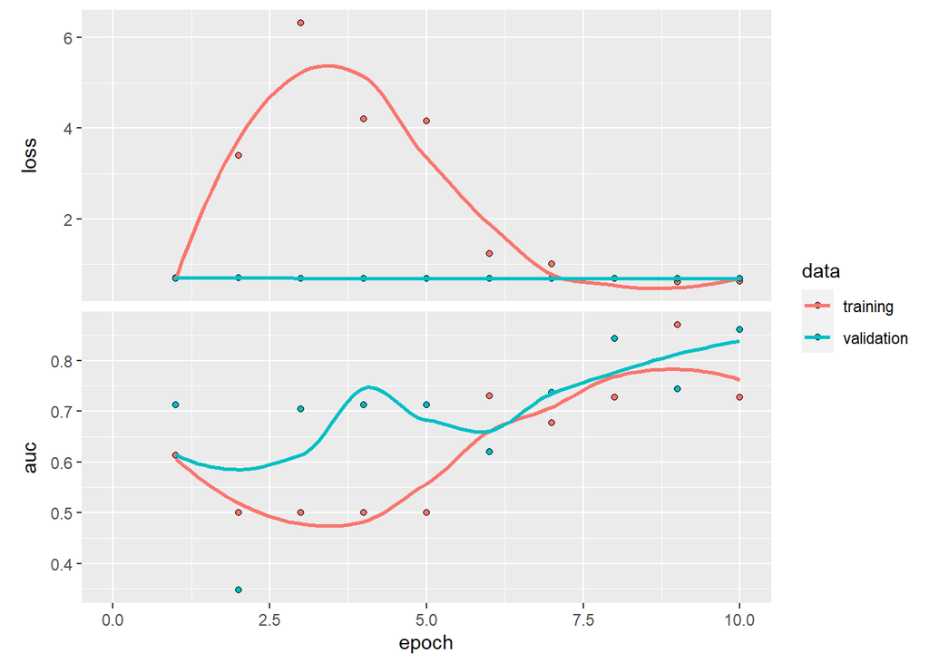

```r
history_cnn <- cnn %>%
    fit_generator(train_generator, steps_per_epoch = 1, epochs = 10,
                  validation_data = valid_generator)
plot(history_cnn) +
  scale_x_continuous(limits = c(0, length(history_cnn$metrics$val_loss)))
```

Сохраним полученную модель

```r
cnn %>% save_model_hdf5("cats_and_dogs.h5")
```